# UKB PRS Analysis

05 April 2023

*Version notes:*

- Publication version

## *ROR-P PRS*

### Load and prep data

```r
datapath = "/Volumes/Shieh-share$/SNPTumor/data/processed/"
load(paste0(datapath, "UKB_cleaned.RData"))
load(paste0(datapath, "snpcoeff_rorp76.RData"))

betas <- snpcoeff_rorp76

# Subset UKB to malignant BC, filter by necessary covar/SNPs
ukb_data <- ukb.noNA.combined_incident %>%
  subset(behavior.1 == 3) %>%
  dplyr::select(eid, breast_death, fu_time, breast_dxage_any, any_of(starts_with("PC")), any_of(rownames(betas))) %>%
  relocate(starts_with("rs"), .after=last_col()) %>%
  relocate(contains(":"), .after=last_col())

wheresnps <- grepl('^rs', colnames(ukb_data))
firstsnpcol <- min(which(wheresnps==T))

# Set missing SNPs in UKB to 0
totcol <- ncol(ukb_data)
snps <- rownames(betas)
inukb <- colnames(ukb_data[,firstsnpcol:totcol])
miss.snps <- setdiff(snps,inukb)

miss.snps.geno <- as.data.frame(matrix(data = 0, nrow = nrow(ukb_data), ncol = length(miss.snps)))
colnames(miss.snps.geno) <- miss.snps
ukb_data <- cbind(ukb_data, miss.snps.geno)
```

### Calculate PRS

```r
ukb_snps <- ukb_data %>% select(all_of(snps))
weighted.score <- as.matrix(ukb_snps) %*% betas$coeff

ukb_results <- cbind(weighted.score, ukb_data[,c(1:(paste0(firstsnpcol-1)))])
ukb_results <- rename(ukb_results, rorp_prs=weighted.score)

print(paste0("Number of SNPs in UKB PRS: ", length(inukb)))
```

```
## [1] "Number of SNPs in UKB PRS: 66"
```

## **Data exploration**

### FIG. S3A: Histogram of ROR-P PRS

```
##   mean_rorp_prs sd_rorp_prs
## 1     -28.16838    5.048287
```

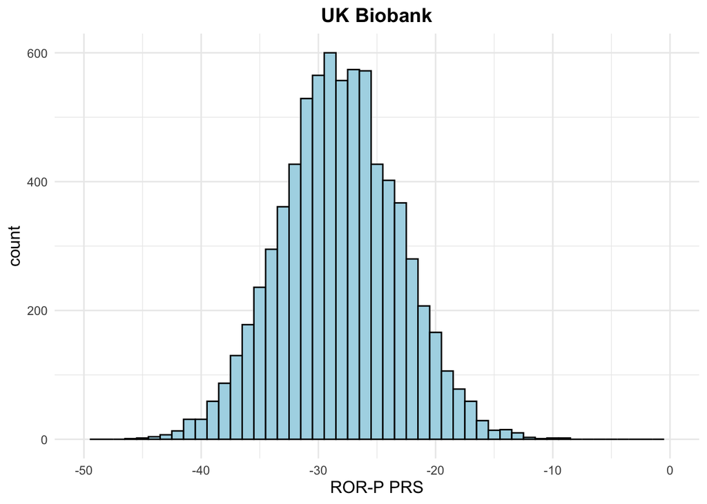

## **Survival analysis**

### Kaplan Meier analysis

```r
ukb_results <- ukb_results %>%
  mutate(prs.tert = ntile(rorp_prs, 3)) %>%
  mutate(fu_yrs = fu_time/365)

km <- with(ukb_results, Surv(fu_yrs, breast_death))
km_pc_fit <- survfit(Surv(fu_yrs, breast_death)~prs.tert, data=ukb_results)
```

### Fig.6A: KM for tertiles of ROR-P PRS

Note: Tertile 1 corresponds to lowest predicted RORP, Tertile 3 corresponds to highest predicted RORP

```
## Call:
## survdiff(formula = km ~ prs.tert, data = ukb_results)
##
##               N Observed Expected (O-E)^2/E (O-E)^2/V
## prs.tert=1 2476      149      181      5.57      8.35
## prs.tert=2 2476      199      182      1.56      2.35
## prs.tert=3 2475      196      181      1.22      1.83
##
##  Chisq= 8.4  on 2 degrees of freedom, p= 0.02
```

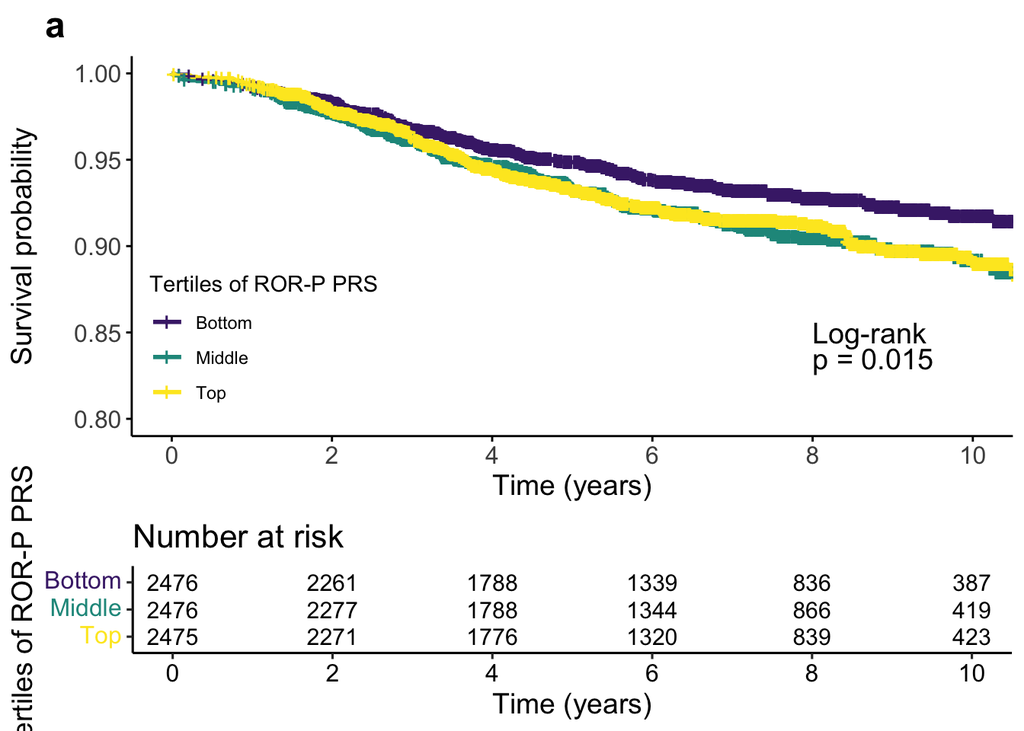

### Normalize PRS for Cox models

```r
ukb_results <- ukb_results %>%
  mutate(mean = mean(rorp_prs, na.rm=T),
         sd = sd(rorp_prs, na.rm=T),
         RORP_norm = (rorp_prs - mean)/sd) %>%
  select(-c(mean, sd))
```

### Cox Model 1, ROR-P PRS + PCs

```r
cox.norm <- coxph(Surv(fu_time, breast_death) ~ RORP_norm + PC1+PC2+PC3+PC4+PC5+PC6+PC7+PC8+PC9+PC10, data=ukb_results)
summary(cox.norm)
```

```
## Call:
## coxph(formula = Surv(fu_time, breast_death) ~ RORP_norm + PC1 +
##     PC2 + PC3 + PC4 + PC5 + PC6 + PC7 + PC8 + PC9 + PC10, data = ukb_results)
##
##   n= 7427, number of events= 544
##
##                coef exp(coef)  se(coef)      z Pr(>|z|)
## RORP_norm  0.119359  1.126774  0.042916  2.781  0.00542 **
## PC1       -0.019528  0.980662  0.023117 -0.845  0.39825
## PC2        0.023581  1.023861  0.026816  0.879  0.37922
## PC3       -0.023805  0.976476  0.026598 -0.895  0.37080
## PC4       -0.014221  0.985879  0.013957 -1.019  0.30825
## PC5        0.006910  1.006934  0.006628  1.043  0.29717
## PC6        0.007994  1.008026  0.025061  0.319  0.74974
## PC7        0.007282  1.007309  0.013954  0.522  0.60177
## PC8        0.001403  1.001404  0.017656  0.079  0.93666
## PC9       -0.013016  0.987068  0.009080 -1.434  0.15171
## PC10      -0.010741  0.989317  0.020033 -0.536  0.59185
## ---
## Signif. codes:  0 '***' 0.001 '**' 0.01 '*' 0.05 '.' 0.1 ' ' 1
##
##           exp(coef) exp(-coef) lower .95 upper .95
## RORP_norm    1.1268     0.8875    1.0359     1.226
## PC1          0.9807     1.0197    0.9372     1.026
## PC2          1.0239     0.9767    0.9714     1.079
## PC3          0.9765     1.0241    0.9269     1.029
## PC4          0.9859     1.0143    0.9593     1.013
## PC5          1.0069     0.9931    0.9939     1.020
## PC6          1.0080     0.9920    0.9597     1.059
## PC7          1.0073     0.9927    0.9801     1.035
## PC8          1.0014     0.9986    0.9673     1.037
## PC9          0.9871     1.0131    0.9697     1.005
## PC10         0.9893     1.0108    0.9512     1.029
##
## Concordance= 0.546  (se = 0.013 )
## Likelihood ratio test= 14.93  on 11 df,   p=0.2
## Wald test            = 14.98  on 11 df,   p=0.2
## Score (logrank) test = 14.95  on 11 df,   p=0.2
```

```r
# Repeat Cox but with normalized PRS
cox.norm <- coxph(Surv(fu_time, breast_death) ~ RORP_norm + PC1+PC2+PC3+PC4+PC5+PC6+PC7+PC8+PC9+PC10 + breast_dxage_any, data=ukb_results)
summary(cox.norm)
```

```
## Call:
## coxph(formula = Surv(fu_time, breast_death) ~ RORP_norm + PC1 +
##     PC2 + PC3 + PC4 + PC5 + PC6 + PC7 + PC8 + PC9 + PC10 + breast_dxage_any,
##     data = ukb_results)
##
##   n= 7427, number of events= 544
##
##                       coef exp(coef)  se(coef)      z Pr(>|z|)
## RORP_norm         0.117969  1.125209  0.042939  2.747  0.00601 **
## PC1              -0.019694  0.980498  0.023256 -0.847  0.39709
## PC2               0.025605  1.025935  0.026873  0.953  0.34069
## PC3              -0.022549  0.977703  0.026618 -0.847  0.39692
## PC4              -0.014632  0.985474  0.013985 -1.046  0.29544
## PC5               0.007981  1.008013  0.006630  1.204  0.22863
## PC6               0.009869  1.009918  0.025108  0.393  0.69427
## PC7               0.008694  1.008732  0.014035  0.619  0.53559
## PC8               0.002350  1.002353  0.017674  0.133  0.89421
## PC9              -0.013200  0.986886  0.009043 -1.460  0.14436
## PC10             -0.011391  0.988674  0.020058 -0.568  0.57011
## breast_dxage_any  0.019616  1.019810  0.005693  3.445  0.00057 ***
## ---
## Signif. codes:  0 '***' 0.001 '**' 0.01 '*' 0.05 '.' 0.1 ' ' 1
##
##                  exp(coef) exp(-coef) lower .95 upper .95
## RORP_norm           1.1252     0.8887    1.0344     1.224
## PC1                 0.9805     1.0199    0.9368     1.026
## PC2                 1.0259     0.9747    0.9733     1.081
## PC3                 0.9777     1.0228    0.9280     1.030
## PC4                 0.9855     1.0147    0.9588     1.013
## PC5                 1.0080     0.9921    0.9950     1.021
## PC6                 1.0099     0.9902    0.9614     1.061
## PC7                 1.0087     0.9913    0.9814     1.037
## PC8                 1.0024     0.9977    0.9682     1.038
## PC9                 0.9869     1.0133    0.9695     1.005
## PC10                0.9887     1.0115    0.9506     1.028
## breast_dxage_any    1.0198     0.9806    1.0085     1.031
##
## Concordance= 0.566  (se = 0.013 )
## Likelihood ratio test= 27.12  on 12 df,   p=0.007
## Wald test            = 26.87  on 12 df,   p=0.008
## Score (logrank) test = 26.91  on 12 df,   p=0.008
```

### FIG. S4: calibration of ROR-P PRS

```r
f <- cph(Surv(fu_time, breast_death) ~ RORP_norm + PC1+PC2+PC3+PC4+PC5+PC6+PC7+PC8+PC9+PC10,
         data = ukb_results,
         x=TRUE, y=TRUE, surv=TRUE, time.inc=365.25*5)

val <- validate(f, B=10, u=365.25*5)

D <- val[1, 5]
cstat <- (0.5*D) + 0.5

#or f <- psm(S ~ \dots)
#pa <- 'polspline' %in% row.names(installed.packages())
#if(pa) {
  #cal <- calibrate(f, u=365.25*5, B=20)  # cmethod='hare'
  #plot(cal)
#}
#cal

cal <- calibrate(f, u=365.25*5, cmethod='KM', m=740, B=200)  # usually B=200 or 300
```

```
## Using Cox survival estimates at 1826.25 dayss
```

```r
cal
```

```
## calibrate.cph(fit = f, cmethod = "KM", u = 365.25 * 5, m = 740,
##     B = 200)
##
##
## n=7427  B=200  u=1826.25 days
##
##          index.orig      training          test mean.optimism mean.corrected
##  [1,] -0.0008012853  1.242651e-03  0.0095488375 -8.306186e-03    0.007504901
##  [2,]  0.0095601597  1.126811e-03  0.0044882107 -3.361400e-03    0.012921560
##  [3,] -0.0006421971  2.066161e-03  0.0039244121 -1.858252e-03    0.001216054
##  [4,] -0.0055213831  2.005880e-03  0.0020221861 -1.630637e-05   -0.005505077
##  [5,]  0.0097208902 -4.840116e-04  0.0002524592 -7.364708e-04    0.010457361
##  [6,] -0.0097050315 -1.208994e-05 -0.0006980069  6.859170e-04   -0.010390949
##  [7,] -0.0059466590 -1.298303e-03 -0.0034214423  2.123140e-03   -0.008069799
##  [8,]  0.0004253368 -1.993230e-03 -0.0043699475  2.376717e-03   -0.001951380
##  [9,] -0.0006813881 -1.689682e-03 -0.0060485167  4.358834e-03   -0.005040222
## [10,]  0.0027612122 -9.929739e-04 -0.0075172399  6.524266e-03   -0.003763054
##         n mean.predicted        KM KM.corrected     std.err
##  [1,] 200      0.9189724 0.9181711    0.9264773 0.011716727
##  [2,] 200      0.9284932 0.9380534    0.9414148 0.010362056
##  [3,] 200      0.9322289 0.9315867    0.9334450 0.010635230
##  [4,] 200      0.9350913 0.9295699    0.9295862 0.010880236
##  [5,] 200      0.9376145 0.9473354    0.9480718 0.009201893
##  [6,] 200      0.9400029 0.9302979    0.9296120 0.010899974
##  [7,] 200      0.9424090 0.9364624    0.9343392 0.010472541
##  [8,] 200      0.9449814 0.9454068    0.9430300 0.009727212
##  [9,] 200      0.9481368 0.9474554    0.9430966 0.009331691
## [10,] 200      0.9541776 0.9569388    0.9504145 0.008557275
```

```
## $groups
##                  n  e      exp          z         p
##  1: <multi-column> 37 39.32602 -0.3709142 0.7107014
##  2: <multi-column> 38 46.04037 -1.1849675 0.2360303
##  3: <multi-column> 52 48.16215  0.5530128 0.5802547
##  4: <multi-column> 56 50.53869  0.7682185 0.4423574
##  5: <multi-column> 56 53.06996  0.4022063 0.6875322
##  6: <multi-column> 55 56.45637 -0.1938271 0.8463113
##  7: <multi-column> 62 56.80997  0.6885850 0.4910845
##  8: <multi-column> 62 60.97956  0.1306754 0.8960321
##  9: <multi-column> 52 62.09375 -1.2809391 0.2002151
## 10: <multi-column> 74 70.52316  0.4140171 0.6788616
##
## $lrTest
## Analysis of Deviance Table
##  Cox model: response is  Surv(fu_time, breast_death)
##  Model 1: ~ RORP_norm + PC1 + PC2 + PC3 + PC4 + PC5 + PC6 + PC7 + PC8 + PC9 + PC10
##  Model 2: ~ RORP_norm + PC1 + PC2 + PC3 + PC4 + PC5 + PC6 + PC7 + PC8 + PC9 + PC10 + indicG
##    loglik  Chisq Df P(>|Chi|)
## 1 -4630.2
## 2 -4627.1 6.1657  9    0.7232
```

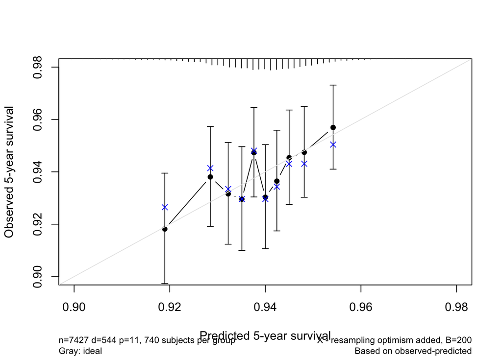

```r
calplot <- plot(cal, xlab = "Predicted 5-year survival", ylab = "Observed 5-year survival",
                xlim = c(0.90, 0.98), ylim = c(0.90, 0.98),
                cuts = c(0.91, 0.92, 0.93, 0.94, 0.95, 0.96),
                subtitles = T)


cox.norm <- coxph(Surv(fu_time, breast_death) ~ RORP_norm + PC1+PC2+PC3+PC4+PC5+PC6+PC7+PC8+PC9+PC10, data=ukb_results)
gof(cox.norm, G=10)
```

### Save calibration plot

```r
png("../output/ukb_calibration_plot.png", width = 6, height=6, units="in", res=600)
calplot <- plot(cal, xlab = "Predicted 5-year survival", ylab = "Observed 5-year survival",
                xlim = c(0.90, 0.98), ylim = c(0.90, 0.98),
                cuts = c(0.91, 0.92, 0.93, 0.94, 0.95, 0.96),
                subtitles = F)
dev.off()
```

## *PRS for ER-negative vs ER-positive disease*

*This is a 193-SNP PRS:*

- Started with 271 SNPs considered for inclusion in the RORP PRS
  - 237 had retrievable summary stats for ER- and ER+ disease in BCAC
  - 205 remained after LD pruning using cutoff of r2 = 0.2
  - 193 were available in UK Biobank
- Used ER-specific ORs from BCAC meta-analysis https://gwas.mrcieu.ac.uk/, datasets eu-a-1127 and eu-a-1128
- Generated case-case betas by subtracting ER+ beta from ER- beta, then converted to OR
- Oriented PRS input so that all ORs >= 1 and risk allele corresponds to the allele conferring greater ER- relative to ER+ risk

### Load and prep ER negative PRS data

```r
# merge in ER-neg PRS
prs_erneg <- read.table(paste0(datapath, "PRS_ukb_prs205.txt"), header=F)

prs_erneg <- prs_erneg %>%
  rename(eid = V1, prs.erneg = V2, race = V3) %>%
  select(-race) %>%
  mutate_at(vars(eid), as.character)

ukb_results <- ukb_results %>% inner_join(prs_erneg, by="eid")
```

## **Survival analysis**

### Kaplan-Meier analysis

```r
ukb_results <- ukb_results %>%
  mutate(prs.erneg.tert = ntile(prs.erneg, 3)) %>%
  mutate(fu_yrs = fu_time/365)

km <- with(ukb_results, Surv(fu_yrs, breast_death))
km_pc_fit_erneg <- survfit(Surv(fu_yrs, breast_death)~prs.erneg.tert, data=ukb_results)
```

### FIG. 6C: KM for tertiles of ER- PRS

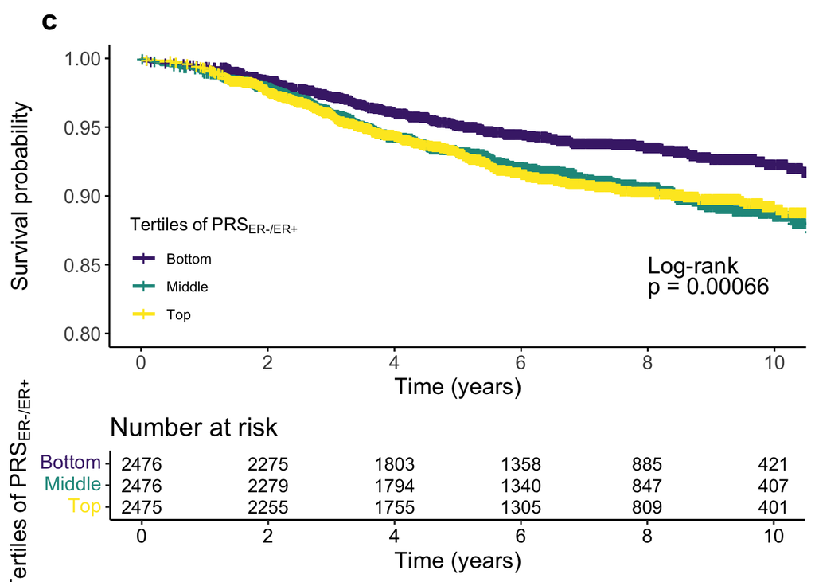

### Normalize ER- PRS for Cox models

```r
ukb_results <- ukb_results %>%
  mutate(mean = mean(prs.erneg, na.rm=T),
         sd = sd(prs.erneg, na.rm=T),
         prs.erneg_norm = (prs.erneg - mean)/sd) %>%
  select(-c(mean, sd))
```

#### ER Cox model 1: ER- PRS + PCs

```r
cox.er1 <- coxph(Surv(fu_time, breast_death)~prs.erneg_norm + PC1+PC2+PC3+PC4+PC5+PC6+PC7+PC8+PC9+PC10, data=ukb_results)
summary(cox.er1)
```

```
## Call:
## coxph(formula = Surv(fu_time, breast_death) ~ prs.erneg_norm +
##     PC1 + PC2 + PC3 + PC4 + PC5 + PC6 + PC7 + PC8 + PC9 + PC10,
##     data = ukb_results)
##
##   n= 7427, number of events= 544
##
##                     coef exp(coef)  se(coef)      z Pr(>|z|)
## prs.erneg_norm  0.138695  1.148774  0.034806  3.985 6.76e-05 ***
## PC1            -0.018594  0.981578  0.023113 -0.804    0.421
## PC2             0.021455  1.021687  0.026787  0.801    0.423
## PC3            -0.025172  0.975142  0.026602 -0.946    0.344
## PC4            -0.014891  0.985219  0.013969 -1.066    0.286
## PC5             0.007532  1.007560  0.006626  1.137    0.256
## PC6             0.007277  1.007303  0.025127  0.290    0.772
## PC7             0.007874  1.007905  0.013982  0.563    0.573
## PC8             0.001089  1.001090  0.017659  0.062    0.951
## PC9            -0.013680  0.986413  0.009062 -1.510    0.131
## PC10           -0.010546  0.989510  0.020004 -0.527    0.598
## ---
## Signif. codes:  0 '***' 0.001 '**' 0.01 '*' 0.05 '.' 0.1 ' ' 1
##
##                exp(coef) exp(-coef) lower .95 upper .95
## prs.erneg_norm    1.1488     0.8705    1.0730     1.230
## PC1               0.9816     1.0188    0.9381     1.027
## PC2               1.0217     0.9788    0.9694     1.077
## PC3               0.9751     1.0255    0.9256     1.027
## PC4               0.9852     1.0150    0.9586     1.013
## PC5               1.0076     0.9925    0.9946     1.021
## PC6               1.0073     0.9927    0.9589     1.058
## PC7               1.0079     0.9922    0.9807     1.036
## PC8               1.0011     0.9989    0.9670     1.036
## PC9               0.9864     1.0138    0.9690     1.004
## PC10              0.9895     1.0106    0.9515     1.029
##
## Concordance= 0.554  (se = 0.013 )
## Likelihood ratio test= 20.89  on 11 df,   p=0.03
## Wald test            = 23.03  on 11 df,   p=0.02
## Score (logrank) test = 22.7  on 11 df,   p=0.02
```

```r
cox.er2 <- coxph(Surv(fu_time, breast_death)~prs.erneg_norm + PC1+PC2+PC3+PC4+PC5+PC6+PC7+PC8+PC9+PC10, data=ukb_results)
summary(cox.er2)
```

```
## Call:
## coxph(formula = Surv(fu_time, breast_death) ~ prs.erneg_norm +
##     PC1 + PC2 + PC3 + PC4 + PC5 + PC6 + PC7 + PC8 + PC9 + PC10,
##     data = ukb_results)
##
##   n= 7427, number of events= 544
##
##                     coef exp(coef)  se(coef)      z Pr(>|z|)
## prs.erneg_norm  0.138695  1.148774  0.034806  3.985 6.76e-05 ***
## PC1            -0.018594  0.981578  0.023113 -0.804    0.421
## PC2             0.021455  1.021687  0.026787  0.801    0.423
## PC3            -0.025172  0.975142  0.026602 -0.946    0.344
## PC4            -0.014891  0.985219  0.013969 -1.066    0.286
## PC5             0.007532  1.007560  0.006626  1.137    0.256
## PC6             0.007277  1.007303  0.025127  0.290    0.772
## PC7             0.007874  1.007905  0.013982  0.563    0.573
## PC8             0.001089  1.001090  0.017659  0.062    0.951
## PC9            -0.013680  0.986413  0.009062 -1.510    0.131
## PC10           -0.010546  0.989510  0.020004 -0.527    0.598
## ---
## Signif. codes:  0 '***' 0.001 '**' 0.01 '*' 0.05 '.' 0.1 ' ' 1
##
##                exp(coef) exp(-coef) lower .95 upper .95
## prs.erneg_norm    1.1488     0.8705    1.0730     1.230
## PC1               0.9816     1.0188    0.9381     1.027
## PC2               1.0217     0.9788    0.9694     1.077
## PC3               0.9751     1.0255    0.9256     1.027
## PC4               0.9852     1.0150    0.9586     1.013
## PC5               1.0076     0.9925    0.9946     1.021
## PC6               1.0073     0.9927    0.9589     1.058
## PC7               1.0079     0.9922    0.9807     1.036
## PC8               1.0011     0.9989    0.9670     1.036
## PC9               0.9864     1.0138    0.9690     1.004
## PC10              0.9895     1.0106    0.9515     1.029
##
## Concordance= 0.554  (se = 0.013 )
## Likelihood ratio test= 20.89  on 11 df,   p=0.03
## Wald test            = 23.03  on 11 df,   p=0.02
## Score (logrank) test = 22.7  on 11 df,   p=0.02
```

## **ROR-P PRS versus PRS for ER- vs ER+ disease**

### FIG. S6A: Correlation between ROR-P PRS and PRS for ER- vs ER+ disease

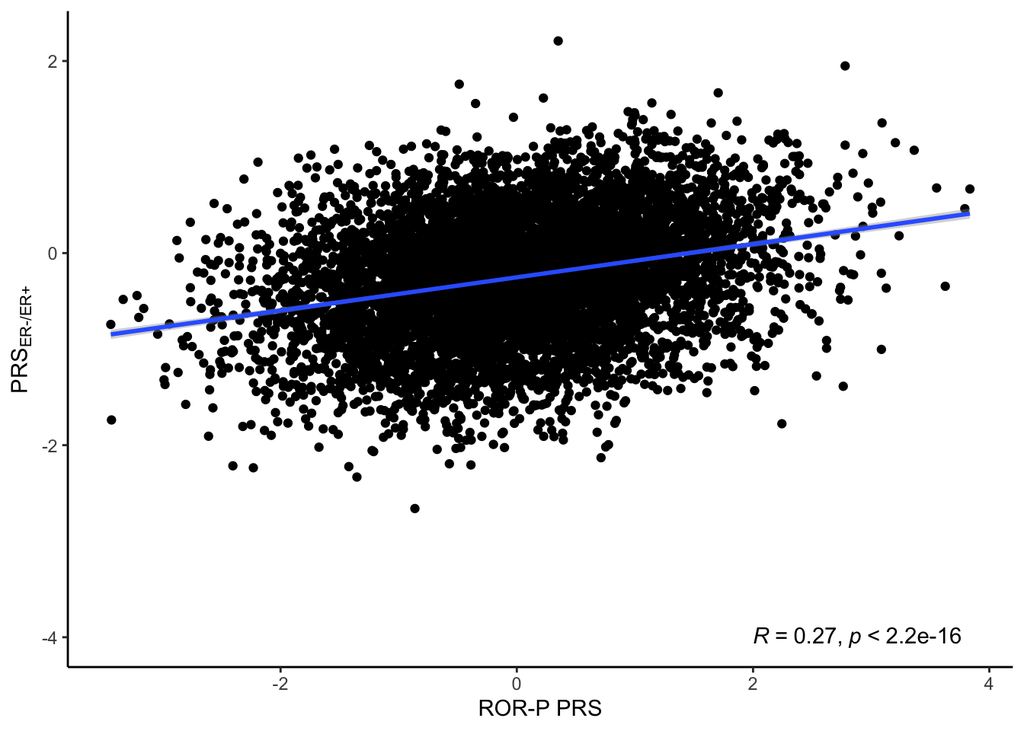

### Joint model

```r
cox.rorp.er <- coxph(Surv(fu_time, breast_death) ~ RORP_norm + prs.erneg_norm + PC1+PC2+PC3+PC4+PC5+PC6+PC7+PC8+PC9+PC10, data=ukb_results)
summary(cox.rorp.er)
```

```
## Call:
## coxph(formula = Surv(fu_time, breast_death) ~ RORP_norm + prs.erneg_norm +
##     PC1 + PC2 + PC3 + PC4 + PC5 + PC6 + PC7 + PC8 + PC9 + PC10,
##     data = ukb_results)
##
##   n= 7427, number of events= 544
##
##                     coef exp(coef)  se(coef)      z Pr(>|z|)
## RORP_norm       0.083750  1.087357  0.044320  1.890  0.05880 .
## prs.erneg_norm  0.120288  1.127821  0.036723  3.276  0.00105 **
## PC1            -0.019094  0.981087  0.023157 -0.825  0.40963
## PC2             0.022682  1.022941  0.026851  0.845  0.39827
## PC3            -0.024539  0.975759  0.026609 -0.922  0.35641
## PC4            -0.015177  0.984938  0.013970 -1.086  0.27731
## PC5             0.007362  1.007389  0.006635  1.110  0.26715
## PC6             0.007179  1.007205  0.025137  0.286  0.77518
## PC7             0.007831  1.007862  0.013987  0.560  0.57555
## PC8             0.001468  1.001469  0.017668  0.083  0.93380
## PC9            -0.013709  0.986384  0.009072 -1.511  0.13075
## PC10           -0.010370  0.989683  0.020007 -0.518  0.60422
## ---
## Signif. codes:  0 '***' 0.001 '**' 0.01 '*' 0.05 '.' 0.1 ' ' 1
##
##                exp(coef) exp(-coef) lower .95 upper .95
## RORP_norm         1.0874     0.9197    0.9969     1.186
## prs.erneg_norm    1.1278     0.8867    1.0495     1.212
## PC1               0.9811     1.0193    0.9376     1.027
## PC2               1.0229     0.9776    0.9705     1.078
## PC3               0.9758     1.0248    0.9262     1.028
## PC4               0.9849     1.0153    0.9583     1.012
## PC5               1.0074     0.9927    0.9944     1.021
## PC6               1.0072     0.9928    0.9588     1.058
## PC7               1.0079     0.9922    0.9806     1.036
## PC8               1.0015     0.9985    0.9674     1.037
## PC9               0.9864     1.0138    0.9690     1.004
## PC10              0.9897     1.0104    0.9516     1.029
##
## Concordance= 0.56  (se = 0.013 )
## Likelihood ratio test= 24.46  on 12 df,   p=0.02
## Wald test            = 26.19  on 12 df,   p=0.01
## Score (logrank) test = 26  on 12 df,   p=0.01
```

## *PRS313 for overall breast cancer*

*39 SNPs not available in UK Biobank, so technically PRS274

### Load and prep PRS data

```r
prs313 <- read.table(paste0(datapath, "PRS_ukb_prs313.txt"), header=F)

prs313 <- prs313 %>%
  rename(eid = V1, prs313 = V2, race = V3) %>%
  select(-race) %>%
  mutate_at(vars(eid), as.character)

ukb_results <- ukb_results %>% inner_join(prs313, by="eid")
```

## **Survival analysis**

### Kaplan Meier

```r
ukb_results <- ukb_results %>%
  mutate(prs313.tert = ntile(prs313, 3)) %>%
  mutate(fu_yrs = fu_time/365)

km <- with(ukb_results, Surv(fu_yrs, breast_death))
km_pc_fit_prs313 <- survfit(Surv(fu_yrs, breast_death)~prs313.tert, data=ukb_results)
```

### FIG. 4: KM for overall BC PRS in tertiles

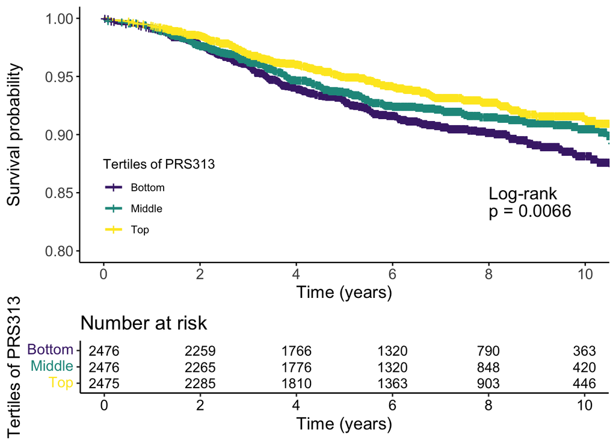

### Normalized PRS313 for Cox model

```r
ukb_results <- ukb_results %>%
  mutate(mean = mean(prs313, na.rm=T),
         sd = sd(prs313, na.rm=T),
         prs313_norm = (prs313 - mean)/sd) %>%
  select(-c(mean, sd))
```

### Cox model 1: adjusted for genetic ancestry

```r
cox.prs313 <- coxph(Surv(fu_time, breast_death)~prs313_norm + PC1+PC2+PC3+PC4+PC5+PC6+PC7+PC8+PC9+PC10, data=ukb_results)
summary(cox.prs313)
```

```
## Call:
## coxph(formula = Surv(fu_time, breast_death) ~ prs313_norm + PC1 +
##     PC2 + PC3 + PC4 + PC5 + PC6 + PC7 + PC8 + PC9 + PC10, data = ukb_results)
##
##   n= 7427, number of events= 544
##
##                  coef exp(coef)  se(coef)      z Pr(>|z|)
## prs313_norm -0.154203  0.857098  0.049589 -3.110  0.00187 **
## PC1         -0.019752  0.980442  0.023172 -0.852  0.39400
## PC2          0.021799  1.022038  0.026697  0.817  0.41419
## PC3         -0.026333  0.974011  0.026578 -0.991  0.32178
## PC4         -0.014877  0.985233  0.013996 -1.063  0.28778
## PC5          0.007075  1.007100  0.006613  1.070  0.28472
## PC6          0.008242  1.008276  0.025022  0.329  0.74186
## PC7          0.007653  1.007683  0.013960  0.548  0.58353
## PC8          0.001191  1.001192  0.017657  0.067  0.94621
## PC9         -0.012368  0.987708  0.009054 -1.366  0.17195
## PC10        -0.010067  0.989983  0.019998 -0.503  0.61469
## ---
## Signif. codes:  0 '***' 0.001 '**' 0.01 '*' 0.05 '.' 0.1 ' ' 1
##
##             exp(coef) exp(-coef) lower .95 upper .95
## prs313_norm    0.8571     1.1667    0.7777    0.9446
## PC1            0.9804     1.0199    0.9369    1.0260
## PC2            1.0220     0.9784    0.9699    1.0769
## PC3            0.9740     1.0267    0.9246    1.0261
## PC4            0.9852     1.0150    0.9586    1.0126
## PC5            1.0071     0.9930    0.9941    1.0202
## PC6            1.0083     0.9918    0.9600    1.0590
## PC7            1.0077     0.9924    0.9805    1.0356
## PC8            1.0012     0.9988    0.9671    1.0364
## PC9            0.9877     1.0124    0.9703    1.0054
## PC10           0.9900     1.0101    0.9519    1.0296
##
## Concordance= 0.558  (se = 0.013 )
## Likelihood ratio test= 17.87  on 11 df,   p=0.08
## Wald test            = 16.93  on 11 df,   p=0.1
## Score (logrank) test = 16.86  on 11 df,   p=0.1
```